# Credit Card Users Churn Prediction

#### Decision Tree Model

```python
dtree = DecisionTreeClassifier(criterion='gini',class_weight={0:0.17,1:0.83},random_state=1)
```

```python
dtree.fit(X_train, y_train)
```

```
DecisionTreeClassifier(class_weight={0: 0.17, 1: 0.83}, random_state=1)
```

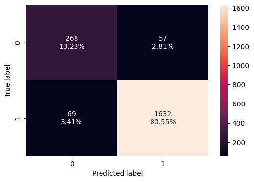

```python
confusion_matrix_sklearn(dtree, X_test, y_test)
```

**Confusion Matrix -**

- The customer renounced their credit card and the model predicted correctly that the customer would attrite : True Positive (observed=1,predicted=1)
  - The model predicted 80% correct which is a pretty good statistic.
- The customer didn't renounce their credit card and the model predicted the customer would attrite : False Positive (observed=0,predicted=1)
- TThe customer didn't renounce their credit card and the model predicted the customer will not attrite: True Negative (observed=0,predicted=0)
- The customer didn't renounce their credit card and the model predicted that the customer won't: False Negative (observed=1,predicted=0)

```python
dtree_model_train_perf=model_performance_classification_sklearn(dtree, X_train, y_train)
print("Training performance \n",dtree_model_train_perf)
```

```
Training performance
    Accuracy  Recall  Precision   F1
0       1.0     1.0        1.0  1.0
```

```python
dtree_model_test_perf=model_performance_classification_sklearn(dtree, X_test, y_test)
print("Testing performance \n",dtree_model_test_perf)
```

```
Testing performance
    Accuracy    Recall  Precision        F1
0  0.937808  0.959436   0.966252  0.962832
```

- From the recall scores on both the training and testing performances, the decision tree model is performing well, with a slight drop in recall on the test data which can be renounced to overfitting.

#### Random Forest

```python
rf = RandomForestClassifier(random_state=1)
rf.fit(X_train,y_train)
```

```
RandomForestClassifier(random_state=1)
```

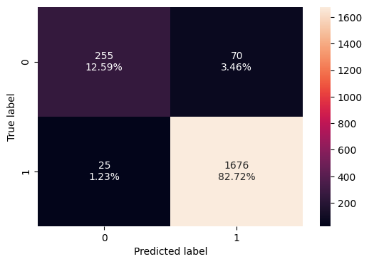

```python
confusion_matrix_sklearn(rf,X_test,y_test)
```

```python
rf_model_train_perf=model_performance_classification_sklearn(rf,X_train,y_train)
print("Training performance \n",rf_model_train_perf)
```

```
Training performance
    Accuracy  Recall  Precision   F1
0       1.0     1.0        1.0  1.0
```

```python
rf_model_test_perf=model_performance_classification_sklearn(rf,X_test,y_test)
print("Testing performance \n",rf_model_test_perf)
```

```
Testing performance
    Accuracy    Recall  Precision       F1
0   0.95311  0.985303   0.959908  0.97244
```

- The random forest performs well in the training scores, although a slight drop in comparison to the testing performances.

#### Bagging Classifier

```python
bagging = BaggingClassifier(random_state=1)
bagging.fit(X_train,y_train)
```

```
BaggingClassifier(random_state=1)
```

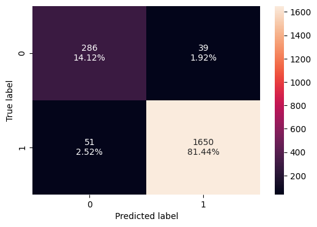

```python
confusion_matrix_sklearn(bagging, X_test, y_test)
```

```python
bagging_model_train_perf=model_performance_classification_sklearn(bagging, X_train, y_train)
print("Training performance \n",bagging_model_train_perf)
```

```
Training performance
    Accuracy    Recall  Precision        F1
0  0.996049  0.996666   0.998624  0.997644
```

```python
bagging_model_test_perf=model_performance_classification_sklearn(bagging, X_test, y_test)
print("Testing performance \n",bagging_model_test_perf)
```

```
Testing performance
    Accuracy    Recall  Precision        F1
0  0.955577  0.970018   0.976909  0.973451
```

- Compared to the random forests training scores, the bagging classifiers' training scores are very slightly down, but the testing performances improved.

#### AdaBoost Classifier

```python
abc = AdaBoostClassifier(random_state=1)
abc.fit(X_train,y_train)
```

```
AdaBoostClassifier(random_state=1)
```

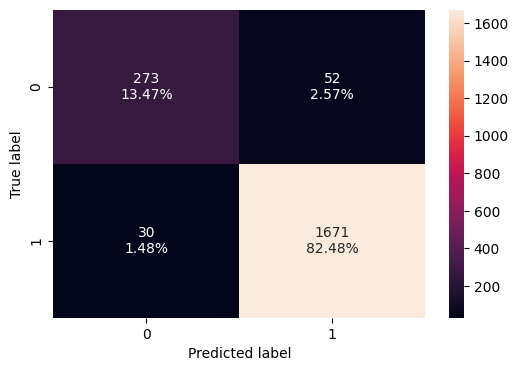

```python
confusion_matrix_sklearn(abc, X_test, y_test)
```

```python
abc_model_train_perf=model_performance_classification_sklearn(abc, X_train, y_train)
print("Training performance \n",abc_model_train_perf)
```

```
Training performance
    Accuracy    Recall  Precision        F1
0  0.963457  0.982546    0.97414  0.978325
```

```python
abc_model_test_perf=model_performance_classification_sklearn(abc, X_test, y_test)
print("Testing performance \n",abc_model_test_perf)
```

```
Testing performance
    Accuracy    Recall  Precision        F1
0  0.959526  0.982363    0.96982  0.976051
```

- Both the training & testing performances are extremely identical to each other in terms of numbers, therefore there is no over/underfitting in the AdaBosst Classifier model.

#### XGBoost Classifier

```python
xgb = XGBClassifier(random_state=1,eval_metric='logloss')
xgb.fit(X_train, y_train)
```

```
XGBClassifier(base_score=None, booster=None, callbacks=None,
              colsample_bylevel=None, colsample_bynode=None,
              colsample_bytree=None, device=None, early_stopping_rounds=None,
              enable_categorical=False, eval_metric='logloss',
              feature_types=None, gamma=None, grow_policy=None,
              importance_type=None, interaction_constraints=None,
              learning_rate=None, max_bin=None, max_cat_threshold=None,
              max_cat_to_onehot=None, max_delta_step=None, max_depth=None,
              max_leaves=None, min_child_weight=None, missing=nan,
              monotone_constraints=None, multi_strategy=None, n_estimators=None,
              n_jobs=None, num_parallel_tree=None, random_state=1, ...)
```

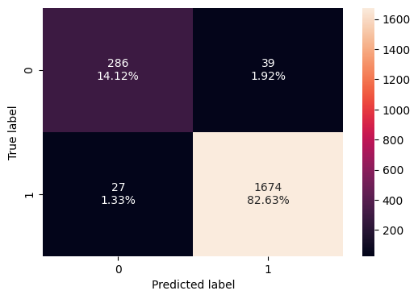

```python
confusion_matrix_sklearn(xgb, X_test, y_test)
```

```python
xgb_model_train_perf=model_performance_classification_sklearn(xgb, X_train, y_train)
print("Training performance \n",xgb_model_train_perf)
```

```
Training performance
    Accuracy  Recall  Precision   F1
0       1.0     1.0        1.0  1.0
```

```python
xgb_model_test_perf=model_performance_classification_sklearn(xgb, X_test, y_test)
print("Testing performance \n",xgb_model_test_perf)
```

```
Testing performance
    Accuracy    Recall  Precision        F1
0  0.967423  0.984127   0.977233  0.980668
```

- Perfect traning performances with a slight decrease in the traning.

### Model Building with Oversampled data

```python
!pip install imblearn
from imblearn.over_sampling import SMOTE # Import the SMOTE class

# Synthetic Minority Over Sampling Technique
sm = SMOTE(sampling_strategy=1, k_neighbors=5, random_state=1)
X_train_over, y_train_over = sm.fit_resample(X_train, y_train)
```

#### Decision Tree Model

```python
dtree_over = DecisionTreeClassifier(criterion='gini',class_weight={0:0.17,1:0.83},random_state=1)
```

```python
dtree_over = dtree_over.fit(X_train_over, y_train_over)
```

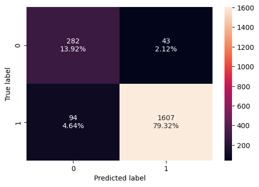

```python
confusion_matrix_sklearn(dtree_over, X_test, y_test)
```

- There seems to be a slight decrease in the number of True Positives compared to the original tree models.

```python
dtree_over_model_train_perf=model_performance_classification_sklearn(dtree_over, X_train_over, y_train_over)
print("Training performance \n",dtree_over_model_train_perf)
```

```
Training performance
    Accuracy  Recall  Precision   F1
0       1.0     1.0        1.0  1.0
```

```python
dtree_over_model_test_perf=model_performance_classification_sklearn(dtree_over, X_test, y_test)
print("Testing performance \n",dtree_over_model_test_perf)
```

```
Testing performance
    Accuracy    Recall  Precision        F1
0  0.932379  0.944738   0.973939  0.959117
```

- Perfect traning performance whilst a good amount of drop from the recall score in the traningshows that the model is overfitting by a minority.

#### Random Forest

```python
rf_over = RandomForestClassifier(random_state=1)
rf_over.fit(X_train_over,y_train_over)
```

```
RandomForestClassifier(random_state=1)
```

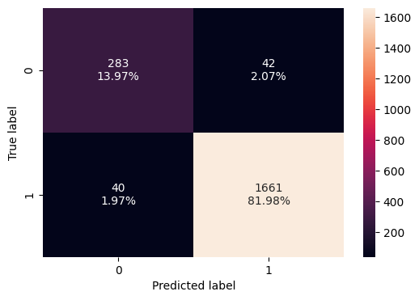

```python
confusion_matrix_sklearn(rf_over, X_test, y_test)
```

- There is about 14% of True Negatives being predicted which is a good sign that the model is predicting the correct negatives and positives.

```python
rf_over_model_train_perf=model_performance_classification_sklearn(rf_over, X_train_over, y_train_over)
print("Training performance \n",rf_over_model_train_perf)
```

```
Training performance
    Accuracy  Recall  Precision   F1
0       1.0     1.0        1.0  1.0
```

```python
rf_over_model_test_perf=model_performance_classification_sklearn(rf_over, X_test, y_test)
print("Testing performance \n",rf_over_model_test_perf)
```

```
Testing performance
    Accuracy    Recall  Precision        F1
0  0.959526  0.976484   0.975338  0.975911
```

- Similar to the Decision Tree Oversampled data model, the traning performances are perfect with the testing being a bit under the par.

#### Bagging Classifier

```python
bagging_over = BaggingClassifier(random_state=1)
bagging_over.fit(X_train_over,y_train_over)
```

```
BaggingClassifier(random_state=1)
```

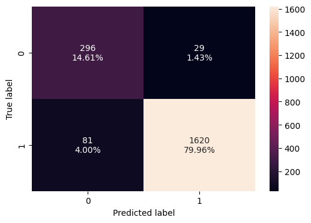

```python
confusion_matrix_sklearn(bagging_over, X_test, y_test)
```

- There is an increase in the True Negatives with a slight decrease in the True Positives compared to the previous oversampled data models.

```python
bagging_over_model_train_perf=model_performance_classification_sklearn(bagging_over, X_train_over, y_train_over)
print("Training performance \n",bagging_over_model_train_perf)
```

```
Training performance
    Accuracy    Recall  Precision        F1
0  0.997058  0.995097   0.999016  0.997052
```

```python
bagging_over_model_test_perf=model_performance_classification_sklearn(bagging_over, X_test, y_test)
print("Testing performance \n",bagging_over_model_test_perf)
```

```
Testing performance
    Accuracy    Recall  Precision        F1
0  0.945706  0.952381   0.982414  0.967164
```

- In this instance, the baggin classifer model with oversampled data is just a fraction off from being completely out performed. With that being said, this model makes it less overfitting from both performances being slightly more close to each other.

#### AdaBoost Classifier

```python
adaboost_over = AdaBoostClassifier(random_state=1)
adaboost_over.fit(X_train_over,y_train_over)
```

```
AdaBoostClassifier(random_state=1)
```

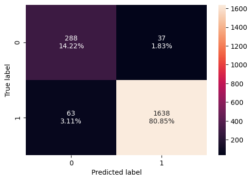

```python
confusion_matrix_sklearn(adaboost_over, X_test, y_test)
```

```python
adaboost_over_model_train_perf=model_performance_classification_sklearn(adaboost_over, X_train_over, y_train_over)
print("Training performance \n",adaboost_over_model_train_perf)
```

```
Training performance
    Accuracy    Recall  Precision        F1
0  0.966072  0.962542   0.969386  0.965952
```

```python
adaboost_over_model_test_perf=model_performance_classification_sklearn(adaboost_over, X_test, y_test)
print("Testing performance \n",adaboost_over_model_test_perf)
```

```
Testing performance
    Accuracy    Recall  Precision        F1
0  0.950642  0.962963    0.97791  0.970379
```

- From the traning and testing performances almost being identical with each other, the model is shown to be well fit with each other and generalized.

#### XGBoost Classifier

```python
xgb_over = XGBClassifier(random_state=1,eval_metric='logloss')
xgb_over.fit(X_train_over, y_train_over)
```

```
XGBClassifier(base_score=None, booster=None, callbacks=None,
              colsample_bylevel=None, colsample_bynode=None,
              colsample_bytree=None, device=None, early_stopping_rounds=None,
              enable_categorical=False, eval_metric='logloss',
              feature_types=None, gamma=None, grow_policy=None,
              importance_type=None, interaction_constraints=None,
              learning_rate=None, max_bin=None, max_cat_threshold=None,
              max_cat_to_onehot=None, max_delta_step=None, max_depth=None,
              max_leaves=None, min_child_weight=None, missing=nan,
              monotone_constraints=None, multi_strategy=None, n_estimators=None,
              n_jobs=None, num_parallel_tree=None, random_state=1, ...)
```

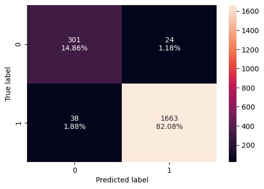

```python
confusion_matrix_sklearn(xgb_over, X_test, y_test)
```

- From all the previous oversampled data models, the xgboost classifier has shown the best true predicted results.

```python
xgb_over_model_train_perf=model_performance_classification_sklearn(xgb_over, X_train_over, y_train_over)
print("Training performance \n",xgb_over_model_train_perf)
```

```
Training performance
    Accuracy  Recall  Precision   F1
0       1.0     1.0        1.0  1.0
```

```python
xgb_over_model_test_perf=model_performance_classification_sklearn(xgb_over, X_test, y_test)
print("Testing performance \n",xgb_over_model_test_perf)
```

```
Testing performance
    Accuracy   Recall  Precision      F1
0  0.969398  0.97766   0.985774  0.9817
```

- Compared to the other models, this model is slightly overfitting but still contains a good generalization.

### Model Building with Undersampled data

```python
!pip install imblearn
from imblearn.under_sampling import RandomUnderSampler

# Random undersampler for under sampling the data
rus = RandomUnderSampler(random_state=1, sampling_strategy=1)
X_train_un, y_train_un = rus.fit_resample(X_train, y_train)
```

#### Decision Tree Model

```python
dtree_un = DecisionTreeClassifier(criterion='gini',class_weight={0:0.17,1:0.83},random_state=1)
```

```python
dtree_un = dtree_un.fit(X_train_un, y_train_un)
```

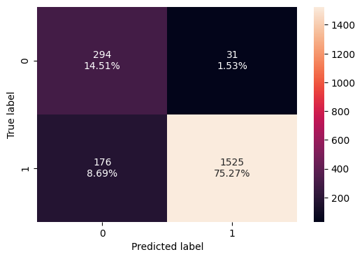

```python
confusion_matrix_sklearn(dtree_un, X_test, y_test)
```

- There is a slight decrease in the number of True Positives in this model compared to the previous ones seen.

```python
dtree_un_model_train_perf=model_performance_classification_sklearn(dtree_un, X_train_un, y_train_un)
print("Training performance \n",dtree_un_model_train_perf)
```

```
Training performance
    Accuracy  Recall  Precision   F1
0       1.0     1.0        1.0  1.0
```

```python
dtree_un_model_test_perf=model_performance_classification_sklearn(dtree_un, X_test, y_test)
print("Testing performance \n",dtree_un_model_test_perf)
```

```
Testing performance
    Accuracy    Recall  Precision        F1
0  0.897828  0.896531   0.980077  0.936445
```

- The training performances seem to be perfect in terms of the scores, however, the accuracy and recall scores for the testing performance are the lowest that has been seen throughout all the models.

#### Random Forest

```python
random_forest_un = RandomForestClassifier(random_state=1)
random_forest_un.fit(X_train_un,y_train_un)
```

```
RandomForestClassifier(random_state=1)
```

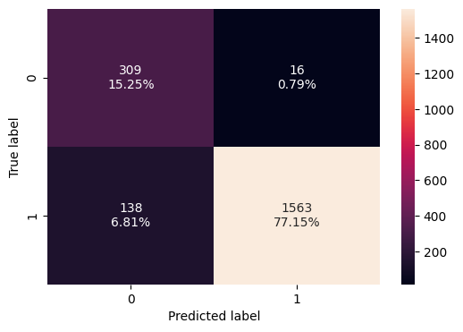

```python
confusion_matrix_sklearn(random_forest_un, X_test, y_test)
```

- The random forest model does slightly better than the decision tree model, there are still signs of overfitting within the model but it is somewhat generalized.

```python
random_forest_un_model_train_perf=model_performance_classification_sklearn(random_forest_un, X_train_un, y_train_un)
print("Training performance \n",random_forest_un_model_train_perf)
```

```
Training performance
    Accuracy  Recall  Precision   F1
0       1.0     1.0        1.0  1.0
```

```python
random_forest_un_model_test_perf=model_performance_classification_sklearn(random_forest_un, X_test, y_test)
print("Testing performance \n",random_forest_un_model_test_perf)
```

```
Testing performance
    Accuracy    Recall  Precision        F1
0  0.923988  0.918871   0.989867  0.953049
```

- The random forest model does slightly better than the decision tree model, there are still signs of overfitting within the model but it is somewhat generalized.

#### Bagging Classifier

```python
bagging_un = BaggingClassifier(random_state=1)
bagging_un.fit(X_train_un,y_train_un)
```

```
BaggingClassifier(random_state=1)
```

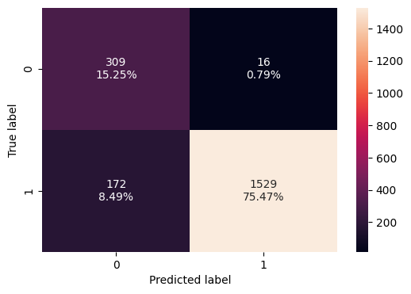

```python
confusion_matrix_sklearn(bagging_un, X_test, y_test)
```

- The true positives has decreased slightly but the true negatives percentage has stayed the same from the previous model.

```python
bagging_un_model_train_perf=model_performance_classification_sklearn(bagging_un, X_train_un, y_train_un)
print("Training performance \n",bagging_un_model_train_perf)
```

```
Training performance
    Accuracy    Recall  Precision        F1
0  0.991291  0.985656   0.996891  0.991242
```

```python
bagging_un_model_test_perf=model_performance_classification_sklearn(bagging_un, X_test, y_test)
print("Testing performance \n",bagging_un_model_test_perf)
```

```
Testing performance
    Accuracy    Recall  Precision        F1
0  0.907206  0.898883   0.989644  0.942083
```

#### AdaBoost Classifier

```python
adaboost_un = AdaBoostClassifier(random_state=1)
adaboost_un.fit(X_train_un,y_train_un)
```

```
AdaBoostClassifier(random_state=1)
```

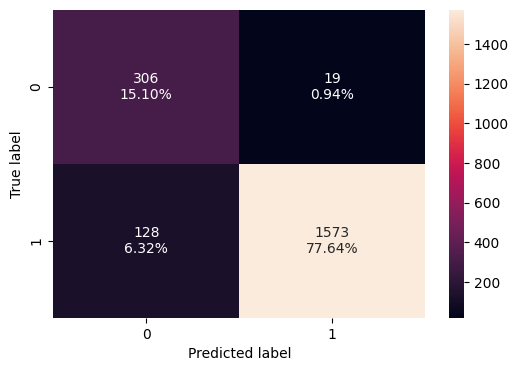

```python
confusion_matrix_sklearn(adaboost_un, X_test, y_test)
```

There is not much that has changed from the previous models with this adaboost confusion matrix.

```python
adaboost_un_model_train_perf=model_performance_classification_sklearn(adaboost_un, X_train_un, y_train_un)
print("Training performance \n",adaboost_un_model_train_perf)
```

```
Training performance
    Accuracy    Recall  Precision        F1
0  0.951332  0.939549   0.962225  0.950752
```

```python
adaboost_un_model_test_perf=model_performance_classification_sklearn(adaboost_un, X_test, y_test)
print("Testing performance \n",adaboost_un_model_test_perf)
```

```
Testing performance
    Accuracy   Recall  Precision       F1
0  0.927443  0.92475   0.988065  0.95536
```

- This model shows a better generalization compared to the rest of the undersampled data models with the training and testing scores having a much lesser gap between them.

#### XGBoost Classifier

```python
xgb_un = XGBClassifier(random_state=1,eval_metric='logloss')
xgb_un.fit(X_train_un, y_train_un)
```

```
XGBClassifier(base_score=None, booster=None, callbacks=None,
              colsample_bylevel=None, colsample_bynode=None,
              colsample_bytree=None, device=None, early_stopping_rounds=None,
              enable_categorical=False, eval_metric='logloss',
              feature_types=None, gamma=None, grow_policy=None,
              importance_type=None, interaction_constraints=None,
              learning_rate=None, max_bin=None, max_cat_threshold=None,
              max_cat_to_onehot=None, max_delta_step=None, max_depth=None,
              max_leaves=None, min_child_weight=None, missing=nan,
              monotone_constraints=None, multi_strategy=None, n_estimators=None,
              n_jobs=None, num_parallel_tree=None, random_state=1, ...)
```

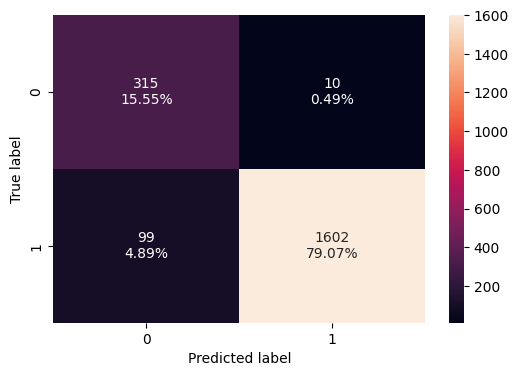

```python
confusion_matrix_sklearn(xgb_un, X_test, y_test)
```

- Just like the previous models, the XGBoost Classifier model has always performed the best with a good increase in true positives in the undersampled models.

```python
xgb_un_model_train_perf=model_performance_classification_sklearn(xgb_un, X_train_un, y_train_un)
print("Training performance \n",xgb_un_model_train_perf)
```

```
Training performance
    Accuracy  Recall  Precision   F1
0       1.0     1.0        1.0  1.0
```

```python
xgb_un_model_test_perf=model_performance_classification_sklearn(xgb_un, X_test, y_test)
print("Testing performance \n",xgb_un_model_test_perf)
```

```
Testing performance
    Accuracy    Recall  Precision        F1
0  0.946199  0.941799   0.993797  0.967099
```

- The is an almost exact balance between the precision scores for the testing and training performances, although compared to the adaboost model it is slightly more overfitted.

### Hyperparameter Tuning

#### Sample Parameter Grids

**Note**

1. Sample parameter grids have been provided to do necessary hyperparameter tuning. These sample grids are expected to provide a balance between model performance improvement and execution time. One can extend/reduce the parameter grid based on execution time and system configuration.
   - Please note that if the parameter grid is extended to improve the model performance further, the execution time will increase
- For Gradient Boosting:

```
param_grid = {
    "init": [AdaBoostClassifier(random_state=1),DecisionTreeClassifier(random_state=1)],
    "n_estimators": np.arange(50,110,25),
    "learning_rate": [0.01,0.1,0.05],
    "subsample":[0.7,0.9],
    "max_features":[0.5,0.7,1],
}
```

- For Adaboost:

```
param_grid = {
    "n_estimators": np.arange(50,110,25),
    "learning_rate": [0.01,0.1,0.05],
    "base_estimator": [
        DecisionTreeClassifier(max_depth=2, random_state=1),
        DecisionTreeClassifier(max_depth=3, random_state=1),
    ],
}
```

- For Bagging Classifier:

```
param_grid = {
    'max_samples': [0.8,0.9,1],
    'max_features': [0.7,0.8,0.9],
    'n_estimators' : [30,50,70],
}
```

- For Random Forest:

```
param_grid = {
    "n_estimators": [50,110,25],
    "min_samples_leaf": np.arange(1, 4),
    "max_features": [np.arange(0.3, 0.6, 0.1),'sqrt'],
    "max_samples": np.arange(0.4, 0.7, 0.1)
}
```

- For Decision Trees:

```
param_grid = {
    'max_depth': np.arange(2,6),
    'min_samples_leaf': [1, 4, 7],
    'max_leaf_nodes' : [10, 15],
    'min_impurity_decrease': [0.0001,0.001]
}
```

- For XGBoost (optional):

```
param_grid={'n_estimators':np.arange(50,110,25),
            'scale_pos_weight':[1,2,5],
            'learning_rate':[0.01,0.1,0.05],
            'gamma':[1,3],
            'subsample':[0.7,0.9]
}
```

#### Example tuning method for Decision tree with original data

```python
# defining model
Model = DecisionTreeClassifier(random_state=1)

# Parameter grid to pass in RandomSearchCV
param_grid = {'max_depth': np.arange(2,6),
              'min_samples_leaf': [1, 4, 7],
              'max_leaf_nodes' : [10,15],
              'min_impurity_decrease': [0.0001,0.001] }

#Calling RandomizedSearchCV
randomized_cv = RandomizedSearchCV(estimator=Model, param_distributions=param_grid, n_iter=10, n_jobs = -1, scoring=scorer, cv=5, random_state=1)

#Fitting parameters in RandomizedSearchCV
randomized_cv.fit(X_train,y_train)

print("Best parameters are {} with CV score={}:" .format(randomized_cv.best_params_,randomized_cv.best_score_))
```

```
Best parameters are {'min_samples_leaf': 7, 'min_impurity_decrease': 0.0001, 'max_leaf_nodes': 15, 'max_depth': 5} with CV score=0.9267489711934156:
```

#### Example tuning method for Decision tree with oversampled data

```python
# defining model
Model = DecisionTreeClassifier(random_state=1)

# Parameter grid to pass in RandomSearchCV
param_grid = {'max_depth': np.arange(2,6),
              'min_samples_leaf': [1, 4, 7],
              'max_leaf_nodes' : [10,15],
              'min_impurity_decrease': [0.0001,0.001] }

#Calling RandomizedSearchCV
randomized_cv = RandomizedSearchCV(estimator=Model, param_distributions=param_grid, n_iter=10, n_jobs = -1, scoring=scorer, cv=5, random_state=1)

#Fitting parameters in RandomizedSearchCV
randomized_cv.fit(X_train_over,y_train_over)

print("Best parameters are {} with CV score={}:" .format(randomized_cv.best_params_,randomized_cv.best_score_))
```

```
Best parameters are {'min_samples_leaf': 7, 'min_impurity_decrease': 0.0001, 'max_leaf_nodes': 15, 'max_depth': 5} with CV score=0.9107692640567754:
```

#### Example tuning method for Decision tree with undersampled data

```python
# defining model
Model = DecisionTreeClassifier(random_state=1)

# Parameter grid to pass in RandomSearchCV
param_grid = {'max_depth': np.arange(2,6),
              'min_samples_leaf': [1, 4, 7],
              'max_leaf_nodes' : [10,15],
              'min_impurity_decrease': [0.0001,0.001] }

#Calling RandomizedSearchCV
randomized_cv = RandomizedSearchCV(estimator=Model, param_distributions=param_grid, n_iter=10, n_jobs = -1, scoring=scorer, cv=5, random_state=1)

#Fitting parameters in RandomizedSearchCV
randomized_cv.fit(X_train_un,y_train_un)

print("Best parameters are {} with CV score={}:" .format(randomized_cv.best_params_,randomized_cv.best_score_))
```

```
Best parameters are {'min_samples_leaf': 7, 'min_impurity_decrease': 0.0001, 'max_leaf_nodes': 15, 'max_depth': 5} with CV score=0.896010230179028:
```

Model Chosen for Original Data

- **Decision Tree Classifier** - Performed the lowest testing performances compared to the other models with original data, will see if hyperparameter tuning can increase the testing performances and make the model less overfitting and more generalized.

Model Chosen for Oversampled Data

- **XGBoost Classifier** - This model was chosen to see if the testing performance metrics would improve and prevent the model further from overfitting.

Model Chosen for Undersampled Data

- **Bagging Classifier** - Contains a really low recall score, will test to see if hypertuning can improve the score and make the model more generalized.

#### Tuning the Decision Tree Classifier model with the Original Data

```python
# Import necessary libraries
from sklearn.tree import DecisionTreeClassifier
from sklearn.model_selection import RandomizedSearchCV
from sklearn.metrics import make_scorer, accuracy_score # Import accuracy_score or any other metric

# defining model
dtree_estimator = DecisionTreeClassifier(random_state=1)

# Parameter grid to pass in RandomSearchCV
param_grid = {
    'max_depth': np.arange(2,6),
    'min_samples_leaf': [1, 4, 7],
    'max_leaf_nodes' : [10, 15],
    'min_impurity_decrease': [0.0001,0.001]
}

# Define a scoring metric
scorer = make_scorer(accuracy_score) # Use accuracy_score or any other relevant metric

#Calling RandomizedSearchCV
dtree_estimator = RandomizedSearchCV(estimator=dtree_estimator, param_distributions=param_grid, n_iter=10, n_jobs = -1, scoring=scorer, cv=5, random_state=1)

#Fitting parameters in RandomizedSearchCV
dtree_estimator.fit(X_train,y_train)

print("Best parameters are {} with CV score={}:" .format(dtree_estimator.best_params_,dtree_estimator.best_score_))
```

```
Best parameters are {'min_samples_leaf': 7, 'min_impurity_decrease': 0.0001, 'max_leaf_nodes': 15, 'max_depth': 5} with CV score=0.9267489711934156:
```

- The model has picked the pest parameters from the paramamter grid.

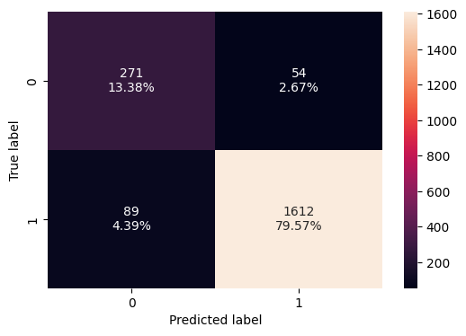

```python
confusion_matrix_sklearn(dtree_estimator, X_test,y_test)
```

```python
dtree_estimator_model_train_perf=model_performance_classification_sklearn(dtree_estimator, X_train,y_train)
print("Training performance \n",dtree_estimator_model_train_perf)
```

```
Training performance
    Accuracy    Recall  Precision        F1
0  0.937449  0.958227    0.96695  0.962569
```

```python
dtree_estimator_model_test_perf=model_performance_classification_sklearn(dtree_estimator, X_test,y_test)
print("Testing performance \n",dtree_estimator_model_test_perf)
```

```
Testing performance
    Accuracy    Recall  Precision        F1
0  0.929418  0.947678   0.967587  0.957529
```

```python
# Viewing the important features in this model

# Access the best estimator from the RandomizedSearchCV object
best_estimator = dtree_estimator.best_estimator_

# Now you can access feature_importances_
print(pd.DataFrame(best_estimator.feature_importances_,
                   columns = ["Imp"],
                   index = X_train.columns).sort_values(by = 'Imp', ascending = False))
```

```
                                     Imp
Total_Trans_Ct                  0.419011
Total_Revolving_Bal             0.265197
Total_Relationship_Count        0.123562
Total_Trans_Amt                 0.118705
Total_Ct_Chng_Q4_Q1             0.061501
Customer_Age                    0.012024
Marital_Status_Married          0.000000
Marital_Status_Single           0.000000
Marital_Status_Unknown          0.000000
Income_Category_$40K - $60K     0.000000
Income_Category_$60K - $80K     0.000000
Education_Level_Uneducated      0.000000
Income_Category_$80K - $120K    0.000000
Income_Category_Less than $40K  0.000000
Card_Category_Gold              0.000000
Card_Category_Platinum          0.000000
Education_Level_Unknown         0.000000
Education_Level_Graduate        0.000000
Education_Level_Post-Graduate   0.000000
Education_Level_High School     0.000000
Dependent_count                 0.000000
Education_Level_Doctorate       0.000000
Gender_M                        0.000000
Avg_Utilization_Ratio           0.000000
Total_Amt_Chng_Q4_Q1            0.000000
Avg_Open_To_Buy                 0.000000
Contacts_Count_12_mon           0.000000
Months_Inactive_12_mon          0.000000
Months_on_book                  0.000000
Card_Category_Silver            0.000000
```

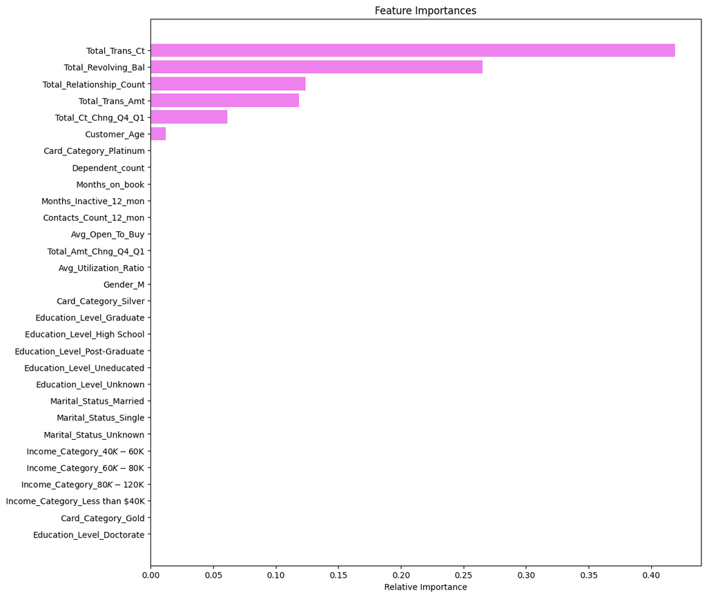

```python
# Visualizing the Important Features

feature_names = X_train.columns
# Access feature importances from the best estimator
importances = dtree_estimator.best_estimator_.feature_importances_
indices = np.argsort(importances)

plt.figure(figsize=(12,12))
plt.title('Feature Importances')
plt.barh(range(len(indices)), importances[indices], color='violet', align='center')
plt.yticks(range(len(indices)), [feature_names[i] for i in indices])
plt.xlabel('Relative Importance')
plt.show()
```

- As seen from the above bar graph, the most important feature for the tuned model is the Total_Trans_Ct by a good margin compared to the others. Following that, the second most relatively important feature is Total_Revolving_Bal and the third is Total_Relationship_Count.

#### Tuning XGBoost Classifier model with the Oversampled Data

```python
# defining model
xgb_estimator = XGBClassifier(random_state=1,eval_metric='logloss')

# Parameter grid to pass in RandomSearchCV
param_grid={'n_estimators':np.arange(50,110,25),
            'scale_pos_weight':[1,2,5],
            'learning_rate':[0.01,0.1,0.05],
            'gamma':[1,3],
            'subsample':[0.7,0.9]
}

#Calling RandomizedSearchCV
xgb_estimator = RandomizedSearchCV(estimator=xgb_estimator, param_distributions=param_grid, n_iter=10, n_jobs = -1, scoring=scorer, cv=5, random_state=1)

#Fitting parameters in RandomizedSearchCV
xgb_estimator.fit(X_train_over,y_train_over)

print("Best parameters are {} with CV score={}:" .format(xgb_estimator.best_params_,xgb_estimator.best_score_))
```

```
Best parameters are {'subsample': 0.7, 'scale_pos_weight': 1, 'n_estimators': 100, 'learning_rate': 0.05, 'gamma': 1} with CV score=0.9672514881381685:
```

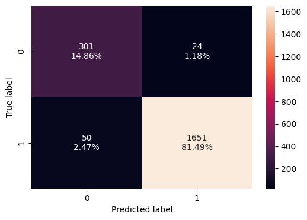

```python
confusion_matrix_sklearn(xgb_estimator, X_test,y_test)
```

```python
xgb_estimator_model_train_perf=model_performance_classification_sklearn(xgb_estimator, X_train,y_train)
print("Training performance \n",xgb_estimator_model_train_perf)
```

```
Training performance
    Accuracy    Recall  Precision        F1
0  0.985021  0.987056   0.995057  0.991041
```

```python
xgb_estimator_model_test_perf=model_performance_classification_sklearn(xgb_estimator, X_test,y_test)
print("Testing performance \n",xgb_estimator_model_test_perf)
```

```
Testing performance
    Accuracy    Recall  Precision        F1
0  0.963475  0.970606   0.985672  0.978081
```

- The training and testing performances did in fact slightly better than the original model due to the results having a lesser gap between each other to reduce overfitting. Furthermore, the recall scores are almost identical with each other in this hyperparameter tuning model which is a good to have since recall is one metric of interest.

```python
# Viewing the important features in this model

# Access the best estimator from the RandomizedSearchCV object
best_estimator = xgb_estimator.best_estimator_

# Now you can access feature_importances_
print(pd.DataFrame(best_estimator.feature_importances_,
                   columns = ["Imp"],
                   index = X_train.columns).sort_values(by = 'Imp', ascending = False))
```

```
                                     Imp
Total_Trans_Ct                  0.233829
Total_Relationship_Count        0.068101
Total_Revolving_Bal             0.067323
Marital_Status_Married          0.064423
Gender_M                        0.062228
Total_Trans_Amt                 0.057586
Marital_Status_Single           0.046159
Total_Ct_Chng_Q4_Q1             0.035686
Education_Level_Unknown         0.026789
Customer_Age                    0.026259
Marital_Status_Unknown          0.023082
Education_Level_Uneducated      0.022723
Months_Inactive_12_mon          0.022500
Total_Amt_Chng_Q4_Q1            0.021623
Avg_Utilization_Ratio           0.021177
Income_Category_Less than $40K  0.020967
Income_Category_$80K - $120K    0.019024
Avg_Open_To_Buy                 0.018691
Income_Category_$40K - $60K     0.018208
Education_Level_Graduate        0.017726
Education_Level_Doctorate       0.017715
Income_Category_$60K - $80K     0.017199
Education_Level_High School     0.016249
Education_Level_Post-Graduate   0.015904
Contacts_Count_12_mon           0.012323
Months_on_book                  0.010606
Card_Category_Silver            0.008266
Dependent_count                 0.007634
Card_Category_Gold              0.000000
Card_Category_Platinum          0.000000
```

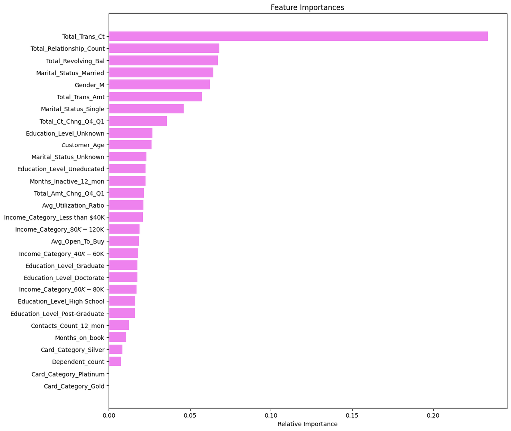

```python
# Visualizing the Important Features

feature_names = X_train.columns
# Access feature importances from the best estimator
importances = xgb_estimator.best_estimator_.feature_importances_
indices = np.argsort(importances)

plt.figure(figsize=(12,12))
plt.title('Feature Importances')
plt.barh(range(len(indices)), importances[indices], color='violet', align='center')
plt.yticks(range(len(indices)), [feature_names[i] for i in indices])
plt.xlabel('Relative Importance')
plt.show()
```

#### Tuning Bagging Classifier with Undersampled Data

```python
# defining model
bagging_estimator = BaggingClassifier(random_state=1)

# Parameter grid to pass in RandomSearchCV
param_grid = {
    'max_samples': [0.8,0.9,1],
    'max_features': [0.7,0.8,0.9],
    'n_estimators' : [30,50,70],
}

#Calling RandomizedSearchCV
bagging_estimator = RandomizedSearchCV(estimator=bagging_estimator, param_distributions=param_grid, n_iter=10, n_jobs = -1, scoring=scorer, cv=5, random_state=1)

#Fitting parameters in RandomizedSearchCV
bagging_estimator.fit(X_train_un,y_train_un)

print("Best parameters are {} with CV score={}:" .format(bagging_estimator.best_params_,bagging_estimator.best_score_))
```

```
Best parameters are {'n_estimators': 70, 'max_samples': 0.9, 'max_features': 0.8} with CV score=0.9385192471637485:
```

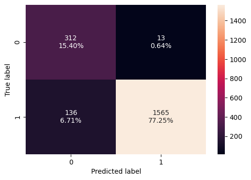

```python
confusion_matrix_sklearn(bagging_estimator, X_test,y_test)
```

```python
bagging_estimator_model_train_perf=model_performance_classification_sklearn(bagging_estimator, X_train_un,y_train_un)
print("Training performance \n",bagging_estimator_model_train_perf)
```

```
Training performance
    Accuracy    Recall  Precision        F1
0  0.998975  0.997951        1.0  0.998974
```

```python
bagging_estimator_model_test_perf=model_performance_classification_sklearn(bagging_estimator, X_test,y_test)
print("Testing performance \n",bagging_estimator_model_test_perf)
```

```
Testing performance
    Accuracy    Recall  Precision        F1
0  0.926456  0.920047   0.991762  0.954559
```

- The hypertuned model does perform better overall in both the training and testing performance metrics compared to the original model. This showcases that the hyperparameter tuning did result in a positive effect.

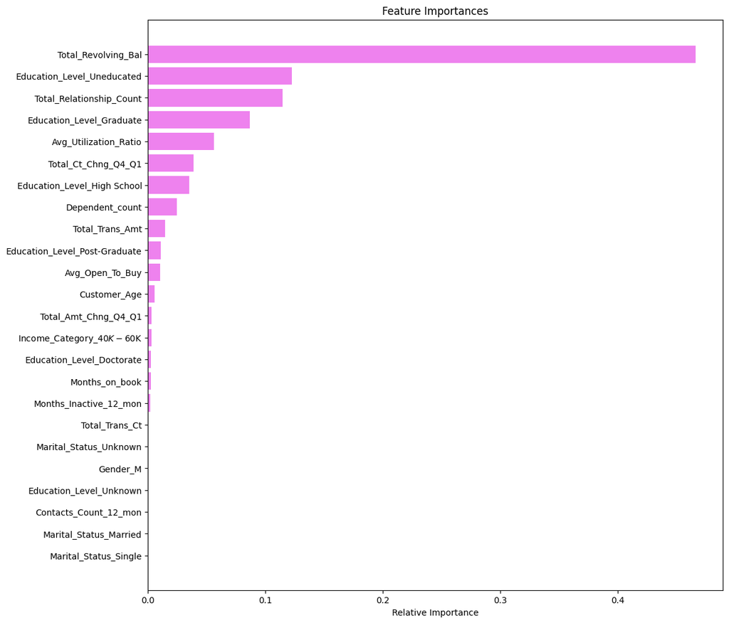

```python
# Visualizing the Important Features

feature_names = X_train.columns

# Assuming your base estimator within BaggingClassifier is a tree-based model
# Access feature importances from the base estimator of the best estimator
importances = bagging_estimator.best_estimator_.estimators_[0].feature_importances_
indices = np.argsort(importances)

plt.figure(figsize=(12,12))
plt.title('Feature Importances')
plt.barh(range(len(indices)), importances[indices], color='violet', align='center')
plt.yticks(range(len(indices)), [feature_names[i] for i in indices])
plt.xlabel('Relative Importance')
plt.show()
```

## Model Comparison and Final Model Selection

### Training set final performance

```python
# Training performance comparison

models_train_comp_df = pd.concat(
    [dtree_model_train_perf.T, dtree_estimator_model_train_perf.T, xgb_model_train_perf.T, xgb_estimator_model_train_perf.T,bagging_model_train_perf.T, bagging_estimator_model_train_perf.T,],
    axis=1,
)
models_train_comp_df.columns = [
    "Decision Tree Classifier (Original Data)",
    "Tuned Decision Tree Classifier (Original Data)",
    "XGBoost Classifier (Oversampled Data)",
    "Tuned XGBoost Classifier (Oversampled Data)",
    "Bagging Classifier (Undersampled Data)",
    "Tuned Bagging Classifier (Undersampled Data)"]
print("Training Performance Comparison:")
models_train_comp_df
```

```
Training Performance Comparison:
```

[output not shown]

### Test set final performance

```python
# Testing performance comparison

models_test_comp_df = pd.concat(
    [dtree_model_test_perf.T, dtree_estimator_model_test_perf.T, xgb_model_test_perf.T, xgb_estimator_model_test_perf.T,bagging_model_test_perf.T, bagging_estimator_model_test_perf.T,],
    axis=1,
)
models_test_comp_df.columns = [
    "Decision Tree Classifier (Original Data)",
    "Tuned Decision Tree Classifier (Original Data)",
    "XGBoost Classifier (Oversampled Data)",
    "Tuned XGBoost Classifier (Oversampled Data)",
    "Bagging Classifier (Undersampled Data)",
    "Tuned Bagging Classifier (Undersampled Data)"]
print("Testing Performance Comparison:")
models_test_comp_df
```

```
Testing Performance Comparison:
```

[output not shown]

#### Feature Importance of Decision Tree

```python
# Access the best estimator from the RandomizedSearchCV object
best_dtree = dtree_estimator.best_estimator_

# Now you can access feature_importances_
print(pd.DataFrame(best_dtree.feature_importances_,
                 columns=["Imp"],
                 index=X_train.columns).sort_values(by='Imp', ascending=False))
```

```
                                     Imp
Total_Trans_Ct                  0.419011
Total_Revolving_Bal             0.265197
Total_Relationship_Count        0.123562
Total_Trans_Amt                 0.118705
Total_Ct_Chng_Q4_Q1             0.061501
Customer_Age                    0.012024
Marital_Status_Married          0.000000
Marital_Status_Single           0.000000
Marital_Status_Unknown          0.000000
Income_Category_$40K - $60K     0.000000
Income_Category_$60K - $80K     0.000000
Education_Level_Uneducated      0.000000
Income_Category_$80K - $120K    0.000000
Income_Category_Less than $40K  0.000000
Card_Category_Gold              0.000000
Card_Category_Platinum          0.000000
Education_Level_Unknown         0.000000
Education_Level_Graduate        0.000000
Education_Level_Post-Graduate   0.000000
Education_Level_High School     0.000000
Dependent_count                 0.000000
Education_Level_Doctorate       0.000000
Gender_M                        0.000000
Avg_Utilization_Ratio           0.000000
Total_Amt_Chng_Q4_Q1            0.000000
Avg_Open_To_Buy                 0.000000
Contacts_Count_12_mon           0.000000
Months_Inactive_12_mon          0.000000
Months_on_book                  0.000000
Card_Category_Silver            0.000000
```

The Transaction Count feature is the most important variable in being able to predict if a customer will renounce their credit cards or not. Furthermore, the secondary important feature following that is the Total Revolving Balance.

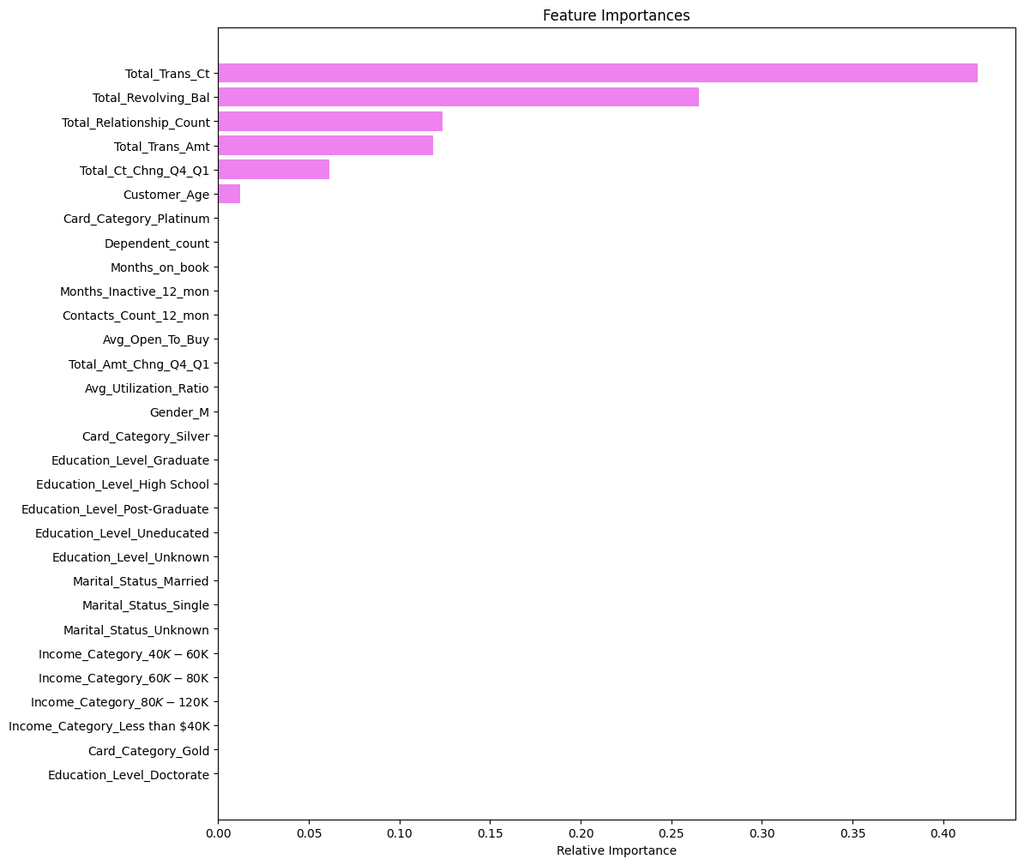

```python
# Access the best estimator from the RandomizedSearchCV object
best_dtree = dtree_estimator.best_estimator_

# Now you can extract the feature importances
importances = best_dtree.feature_importances_
indices = np.argsort(importances)

plt.figure(figsize=(12,12))
plt.title('Feature Importances')
plt.barh(range(len(indices)), importances[indices], color='violet', align='center')
plt.yticks(range(len(indices)), [feature_names[i] for i in indices])
plt.xlabel('Relative Importance')
plt.show()
```

# Business Insights and Conclusions

Business Insights

- Factors that drive attrition are the total transaction account, total revolving balance, and total relationship count.
- Total Transaction Count: Customers who are not active or with a low amount of transactions over the past year tend to Attrite more due to inactivity. Therefore, Thera Bank should make sure that all the customers are pleased with their service and not having a disappointing experience.
- Total Revolving Balance: Those customers who have a large amount of revolving balance might indicate that the customer is having difficulty in managing their debt which could possibly lead to being attrited. The Thera Bank needs to provide the customers who are in this position financial advising sessions if not already, as well as providing insights/advice to the customers in need.
- Total Relationship Count: Customers who have a minor amount of products in a relationship with Thera Bank will most likely end up churning over those who have a good amount of products. The bank can use this information to focus more on retention strategies, for instance offering them personalized deals in order for them to be engaged and encouraged with the bank.
- Total Transaction Amount: Similar to the total transaction account, those customers with a low transaction over the past year may either indicate that the customer doesn't have the income to be spending, or the customer doesn't find the usage bank's credit card and prefers to use another. On the contrary, those customers with high transaction amounts could be loyal and wealthy customers with high spending habits. In order for the bank to help those with low transaction amounts on a yearly basis, Thera Bank should offer personalized rewards or cashback on certain categories that the customers frequently spend upon. This can be groceries, dining, or traveling.
- Ratio of Total Transaction Account (4th Qtr to 1st Qtr): Those customers with a small ratio of transactions may lead to attrition, some of them could be in early indicators as well, thus prompting the bank to intervene with retention strategies.
- Customer Age: Those customers who are in certain age groups such as young adults, middle-aged, and older can have a varying likelihood of being attracted or not. The bank needs to offer certain age groups their related rewards. For example, for young adults, the bank could offer student credit cards with lower credit limits and benefits students such as cashback textbooks or dining. For older adults, offer retirement planning products like credit cards with benefits related to health, and leisure, and provide retirement savings accounts.

Recommendations

- Enhance customer engagement and retention, features such as total transaction amount & count can depict high-value customers and tailor loyalty programs and personalized offers to encourage them to continue the relationship with Thera Bank.
- Implement targeted financial products and services to specific demographics, using features such as the age of the customers, their income, and their educational background. The bank could design and offer financial products that can cater to those specific groups of customers.
- Focus on churn prevention and risk management, features like the number of months inactive in a year and the ratio of transaction count from the 1st quarter to the 4th can be used to identify customers who may be at risk of attracting. Thera Bank should develop strategies such as personalized outreach or exclusive offers to those customers.